# A Nuts Problem | Assignment 4

Davide Pecchia

1/5/2018

## Introduction

The **Molokai Nut Company (MNC)** makes four different products from *macadamia nuts* grown in the Hawaiian Islands:

- *chocolate-coated whole nuts* (**Whole**),
- *chocolate-coated nut clusters* (**Cluster**),
- *chocolate-coated nut crunch bars* (**Crunch**), and
- *plain roasted nuts* (**Roasted**).

The company is barely able to keep up with the increasing demand for these products. However, increasing raw material prices and foreign competition are forcing MNC to watch its margins to ensure it is operating in the most efficient manner possible.

## Marketing Demands

To meet marketing demands for the coming week, MNC needs to produce

- at least 1,000 pounds of the Whole product,
- between 400 and 500 pounds of the Cluster product,
- no more than 150 pounds of the Crunch product, and
- no more than 200 pounds of Roasted product.

## Production Requirements

Each pound of the Whole, Cluster, Crunch, and Roasted product contains, respectively, 60%, 40%, 20%, and 100% macadamia nuts with the remaining weight made up of chocolate coating.

The company has 1100 pounds of nuts and 800 pounds of chocolate available for use in the next week.

The various products are made using four different machines that hull the nuts, roast the nuts, coat the nuts in chocolate (if needed), and package the products.

The following table summarizes the time required by each product on each machine. Each machine has 60 hours of time available in the coming week.

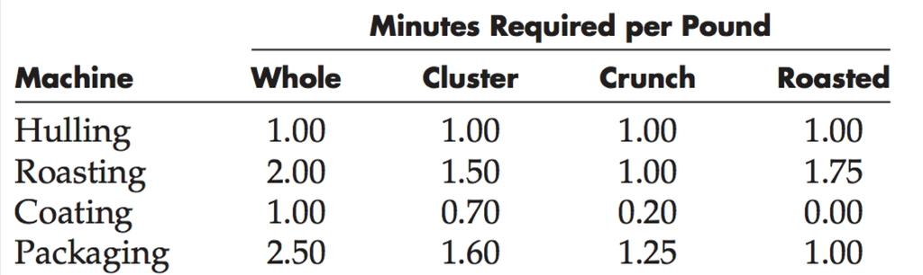

Minutes Required per Pound

## Financial Summary

The controller recently presented management with the following financial summary of MNC’s average weekly operations over the past quarter. From this report, the controller is arguing that the company should cease producing its Cluster and Crunch products.

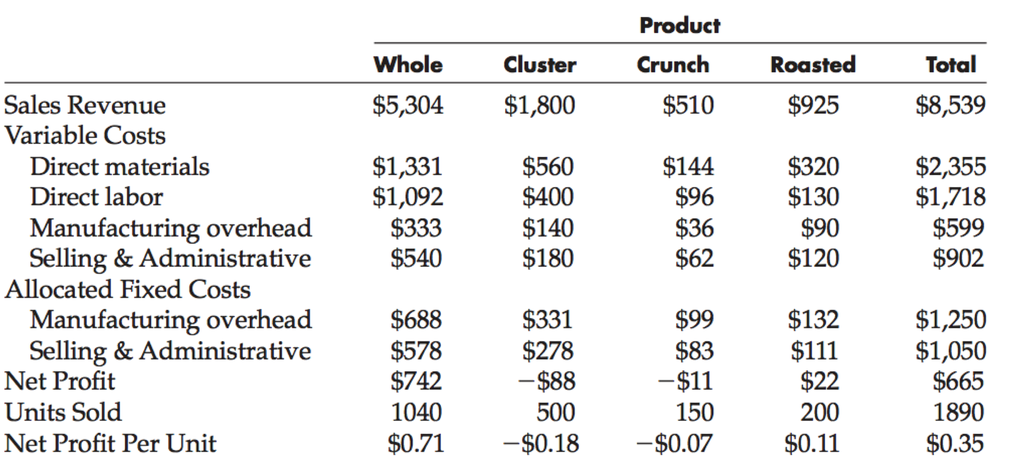

Financial Summary

## Questions

**a. Do you agree with the controller’s recommendation? Why or why not?**

```r
#calculating the variable costs
var_whole <- 1331 + 1092 + 333 + 540
var_cluster <- 560 + 400 + 140 + 180
var_crunch <- 144 + 96 + 36 + 62
var_roasted <- 320 + 130 + 90 + 120
total_variable_costs <- 2355 + 1718 + 599 + 902

#calculating the fixed costs
fixed_whole <- 688 + 578
fixed_cluster <- 331 + 278
fixed_crunch <- 99 + 83
fixed_roasted <- 132 + 111
total_fixed_costs <- 1250 + 1050

#calculating the coefficients by removing the variables costs from the Sales revenue
#and than dividing for the number of units sold

whole <- (5304 - var_whole) / 1040
cluster <- (1800 - var_cluster) / 500
crunch <- (510 - var_crunch) / 150
roasted <- (925 - var_roasted) / 200
c(whole, cluster, crunch, roasted)
```

```
[1] 1.930769 1.040000 1.146667 1.325000
```

To answer the question and check the controller’s recommendation, it’useful to calculate the net profit taking into account the variable costs only, cause the fixed costs are always the same. It emerges that the revenue is positive also for Cluster and Crunch products so making a decision without other calculations is not a good idea. However, i agree with the controller’s recommendation cause the 2 products seem to be the less profitable ones.

**b. Formulate an LP model for this problem.**

$x_1$ = whole

$x_2$ = cluster

$x_3$ = crunch

$x_4$ = roasted

Objective function (no fixed costs): $1.930769 \cdot x_1 + 1.04 \cdot x_2 + 1.146667 \cdot x_3 + 1.325 \cdot x_4$

Marketing demands for the coming week: $x_1 \geq 1000$ ; $400 \leq x_2 \leq 500$ ; $x_3 \leq 150$ ; $x_4 \leq 200$

Production requirements (nuts): $0.6 \cdot x_1 + 0.4 \cdot x_2 + 0.2 \cdot x_3 + 1 \cdot x_4 \leq 1100$

Production requirements (chocolate): $0.4 \cdot x_1 + 0.6 \cdot x_2 + 0.8 \cdot x_3 \leq 800$

Production requirements (machine | hulling): $x_1 + x_2 + x_3 + x_4 \leq 3600$ (60 minutes * 60 hours = 3600 minutes)

Production requirements (machine | roasting): $2.00 \cdot x_1 + 1.50 \cdot x_2 + 1.00 \cdot x_3 + 1.75 \cdot x_4 \leq 3600$

Production requirements (machine | coating): $1.00 \cdot x_1 + 0.70 \cdot x_2 + 0.20 \cdot x_3 + 0.00 \cdot x_4 \leq 3600$

Production requirements (machine | packaging): $2.50 \cdot x_1 + 1.60 \cdot x_2 + 1.25 \cdot x_3 + 1.00 \cdot x_4 \leq 3600$

Non negative production: $x_1, x_2, x_3, x_4 \geq 0$

**c. Create a executable model in R for this problem and solve it.**

```r
#loading libraries
library(knitr)
library(lpSolveAPI)
library(lpSolve)
```

```r
#lp model
lp_model <- make.lp(0,4)
lp.control(lp_model, sense="max")
set.objfn(lp_model, c(whole,cluster,crunch,roasted))

#adding rows
row.add.mode(lp_model,"on")

add.constraint(lp_model,
               xt = c(0.6,0.4,0.2,1),
               type = "<=",
               rhs = 1100,
               indices = c(1:4))
add.constraint(lp_model,
               xt = c(0.4,0.6,0.8),
               type = "<=",
               rhs=800,
               indices = c(1:3))
add.constraint(lp_model,
               xt = c(1,1,1,1),
               type = "<=",
               rhs = 3600,
               indices = c(1:4))
add.constraint(lp_model,
               xt = c(2.00,1.50,1.00,1.75),
               type = "<=",
               rhs = 3600,
               indices = c(1:4))
add.constraint(lp_model,
               xt = c(1.00,0.70,0.20),
               type = "<=",
               rhs = 3600,
               indices = c(1:3))
add.constraint(lp_model,
               xt = c(2.50,1.60,1.25,1.00),
               type = "<=",
               rhs = 3600,
               indices = c(1:4))
add.constraint(lp_model,
               xt = c(1,0,0,0),
               type = ">=",
               rhs = 1000,
               indices = c(1:4))
add.constraint(lp_model,
               xt = c(0,1,0,0),
               type = "<=",
               rhs = 500,
               indices = c(1:4))
add.constraint(lp_model,
               xt = c(0,1,0,0),
               type = ">=",
               rhs = 400,
               indices = c(1:4))
add.constraint(lp_model,
               xt = c(0,0,1,0),
               type = "<=",
               rhs = 150,
               indices = c(1:4))
add.constraint(lp_model,
               xt = c(0,0,0,1),
               type = "<=",
               rhs = 200,
               indices = c(1:4))

row.add.mode(lp_model,"off")
```

```r
#result
res <- solve(lp_model)
res #if res = 0 there's a solution!
```

```
[1] 0
```

```r
#number of units per product
units_per_prod <- get.variables(lp_model)
units_per_prod
```

```
[1] 1029  400  150  200
```

```r
#calculating the total variable profit
var_profit <- get.objective(lp_model)
var_profit
```

```
[1] 2839.762
```

```r
#calculating the total net profit
net_profit <- var_profit - total_fixed_costs
net_profit
```

```
[1] 539.7615
```

```r
#printing the model
print.lpExtPtr(lp_model)
```

```
Model name:
                      C1              C2              C3              C4
Maximize   1.93076923077            1.04  1.146666666666           1.325
R1                   0.6             0.4             0.2               1  <=  1100
R2                   0.4             0.6             0.8               0  <=   800
R3                     1               1               1               1  <=  3600
R4                     2             1.5               1            1.75  <=  3600
R5                     1             0.7             0.2               0  <=  3600
R6                   2.5             1.6            1.25               1  <=  3600
R7                     1               0               0               0  >=  1000
R8                     0               1               0               0  <=   500
R9                     0               1               0               0  >=   400
R10                    0               0               1               0  <=   150
R11                    0               0               0               1  <=   200
Kind                 Std             Std             Std             Std
Type                Real            Real            Real            Real
Upper                Inf             Inf             Inf             Inf
Lower                  0               0               0               0
```

**d. What is the optimal solution?**

Producing 1029 units of *chocolate-coated whole nuts* (**Whole**), 400 units of *chocolate-coated nut clusters* (**Cluster**), 150 units of *chocolate-coated nut crunch bars* (**Crunch**) and 200 units of *plain roasted nuts* (**Roasted**) would be the optimal solution.

**e. Perform the sensitivity analysis for this solution and answer the following questions.**

```r
require(dplyr)
require(tidyr)
```

```r
printSensitivityRHS <- function(model){

  options(scipen=999)
  arg.rhs =get.sensitivity.rhs(model)
  numRows <- length(arg.rhs$duals)

   symb <- c()
   for (i in c(1:numRows)) {
     symb[i] <- paste("B", i, sep = "" )
   }

  rhs <- data.frame(rhs = symb,arg.rhs)

  rhs<-rhs %>%
  mutate(dualsfrom=replace(dualsfrom, dualsfrom < -1000, "-inf")) %>%
  mutate(dualstill=replace(dualstill, dualstill > 10000, "inf")) %>%
    unite(col = "Sensitivity",
          dualsfrom, rhs, dualstill ,
          sep = " <= ", remove = FALSE) %>%
    select(c("rhs","duals", "Sensitivity"))

  colnames(rhs)[1]<-c('Rhs')
  print(rhs)
}
```

```r
printSensitivityObj <- function(model){
  options(scipen=999)
  arg.obj = get.sensitivity.obj(model)

  numRows <- length(arg.obj$objfrom)
   symb <- c()
   for (i in c(1:numRows)) {
     symb[i] <- paste("C", i, sep = "" )
   }

  obj <- data.frame(Objs = symb, arg.obj)

  obj<-
    obj %>%
    mutate(objfrom=replace(objfrom, objfrom < -1000, "-inf")) %>%
    mutate(objtill=replace(objtill, objtill > 1000, "inf")) %>%
    unite(col = "Sensitivity",
          objfrom, Objs, objtill ,
          sep = " <= ", remove = FALSE) %>%
    select(c("Objs","Sensitivity"))
    print(obj)
}
```

```r
printSensitivityObj(lp_model)
```

```
  Objs                   Sensitivity
1   C1 1.625 <= C1 <= 2.293333333332
2   C2 -inf <= C2 <= 1.2356923076928
3   C3   0.965384615385 <= C3 <= inf
4   C4   0.772307692308 <= C4 <= inf
```

Which indicates that the base will remain if:

$1.625 \leq C1 \leq 2.293333333332$

$-inf \leq C2 \leq 1.2356923076928$

$0.965384615385 \leq C3 \leq inf$

```r
SensitivityRHS <- printSensitivityRHS(lp_model)
```

```
   Rhs      duals                      Sensitivity
1   B1  0.0000000                -inf <= B1 <= inf
2   B2  0.0000000                -inf <= B2 <= inf
3   B3  0.0000000                -inf <= B3 <= inf
4   B4  0.0000000                -inf <= B4 <= inf
5   B5  0.0000000                -inf <= B5 <= inf
6   B6  0.7723077           3527.5 <= B6 <= 3777.5
7   B7  0.0000000                -inf <= B7 <= inf
8   B8  0.0000000                -inf <= B8 <= inf
9   B9 -0.1956923              0 <= B9 <= 445.3125
10 B10  0.1812821     0 <= B10 <= 197.333333333334
11 B11  0.5526923 22.4999999999992 <= B11 <= 272.5
12 B12  0.0000000               -inf <= B12 <= inf
13 B13  0.0000000               -inf <= B13 <= inf
14 B14  0.0000000               -inf <= B14 <= inf
15 B15  0.0000000               -inf <= B15 <= inf
```

From the analysis emerges that, as we can see from the dual values, zero shadow prices mean that small changes in the availability of nuts and chocolate, in hulling, roasting and coating machine time do not affect the solution. However, increasing by a minute the availability of the packaging machine leads to an improvement of 0.77 of the optimal value (not changing the base).

**f. Is the solution degenerate?**

```r
solve.lpExtPtr(lp_model)
```

```
[1] 0
```

The output code “0” of the function means that an optimal solution has been found. In case we had a degenerate solution, the output code would have been “4”.

**g. Is the solution unique?**

```r
get.solutioncount(lp_model)
```

```
[1] 1
```

The solution is unique.

**h. If MNC wanted to decrease the production on any product, which one would you recommend and why?**

```r
shadow_prices <- data.frame(Name = c("Nuts", "Chocolate",
                                     "Hulling", "Roasting", "Coating", "Packaging",
                                     "min Whole", "min Cluster", "max Cluster", "max Crunch", "max Roasted",
                                     "/", "/", "/", "/"),
                            Shadow_price = SensitivityRHS$duals)
kable(shadow_prices)
```

| Name | Shadow_price |
| --- | --- |
| Nuts | 0.0000000 |
| Chocolate | 0.0000000 |
| Hulling | 0.0000000 |
| Roasting | 0.0000000 |
| Coating | 0.0000000 |
| Packaging | 0.7723077 |
| min Whole | 0.0000000 |
| min Cluster | 0.0000000 |
| max Cluster | -0.1956923 |
| max Crunch | 0.1812821 |
| max Roasted | 0.5526923 |
| / | 0.0000000 |
| / | 0.0000000 |
| / | 0.0000000 |
| / | 0.0000000 |

I would recommend to decrease the production of **Cluster**, cause it is the only one that has a negative shadow price (an increase of one unit causes a decrease of the optimal value). This product also has the lowest margin between price and variable costs ($C2$).

**j. Which resources are preventing MNS from making more money? If they could acquire more of this resource how much should they acquire & how much should they be willing to pay to acquire it?**

```r
df<- data.frame(Name = c("Nuts", "Chocolate",
                         "Hulling", "Roasting", "Coating", "Packaging",
                         "min Whole", "min Cluster", "max Cluster", "max Crunch", "max Roasted"),
                Limits = get.constr.value(lp_model),
                Values = get.constraints(lp_model))
kable(df)
```

| Name | Limits | Values |
| --- | --- | --- |
| Nuts | 1100 | 1007.4 |
| Chocolate | 800 | 771.6 |
| Hulling | 3600 | 1779.0 |
| Roasting | 3600 | 3158.0 |
| Coating | 3600 | 1339.0 |
| Packaging | 3600 | 3600.0 |
| min Whole | 1000 | 1029.0 |
| min Cluster | 500 | 400.0 |
| max Cluster | 400 | 400.0 |
| max Crunch | 150 | 150.0 |
| max Roasted | 200 | 200.0 |

The packaging machine is the only one that reaches the time limit. The production could be improved by acquiring more minutes for the packaging machine, till a maximum of 3777.5 minutes, at a cost of $0.77230077 per minute. So:

```r
packaging_time_increase <- 3777.5 - 3600
tot_cost <- packaging_time_increase*0.77230077
tot_cost
```

```
[1] 137.0834
```

The production could be incresed by paying $137.0834

**k. How much should MNC be willing to pay to acquire more chocolate?**

No need to pay to acquire more chocolate cause the shadow price is 0

**l. If the marketing department wanted to decrease the price of the Whole product by $0.25, would the optimal solution change?**

```r
printSensitivityObj(lp_model)
```

```
  Objs                   Sensitivity
1   C1 1.625 <= C1 <= 2.293333333332
2   C2 -inf <= C2 <= 1.2356923076928
3   C3   0.965384615385 <= C3 <= inf
4   C4   0.772307692308 <= C4 <= inf
```

Decreasing the price of **Whole** product means reducing $C1 = 1.930769$ by 0.25. So the new value of $C1$ will be $1.680769$, which remains into the interval so it doesn’t affect the optimal solution.